# hw4_data412_SydneyBall

Sydney Ball

2024-02-15

####Import Libraries

```r
library(tidyverse)
```

####Question 2: How many mammals are in the msleep data frame? How many variables? Use two R functions to get this information.

```r
msleep
```

```
## # A tibble: 83 × 11
##    name   genus vore  order conservation sleep_total sleep_rem sleep_cycle awake
##    <chr>  <chr> <chr> <chr> <chr>              <dbl>     <dbl>       <dbl> <dbl>
##  1 Cheet… Acin… carni Carn… lc                  12.1      NA        NA      11.9
##  2 Owl m… Aotus omni  Prim… <NA>                17         1.8      NA       7
##  3 Mount… Aplo… herbi Rode… nt                  14.4       2.4      NA       9.6
##  4 Great… Blar… omni  Sori… lc                  14.9       2.3       0.133   9.1
##  5 Cow    Bos   herbi Arti… domesticated         4         0.7       0.667  20
##  6 Three… Brad… herbi Pilo… <NA>                14.4       2.2       0.767   9.6
##  7 North… Call… carni Carn… vu                   8.7       1.4       0.383  15.3
##  8 Vespe… Calo… <NA>  Rode… <NA>                 7        NA        NA      17
##  9 Dog    Canis carni Carn… domesticated        10.1       2.9       0.333  13.9
## 10 Roe d… Capr… herbi Arti… lc                   3        NA        NA      21
## # ℹ 73 more rows
## # ℹ 2 more variables: brainwt <dbl>, bodywt <dbl>
```

```r
NCOL(msleep)
```

```
## [1] 11
```

```r
NROW(msleep)
```

```
## [1] 83
```

There are 83 animals (mammals) and there are 11 variable total.

####Question 3: Plot “Body Weight” against the “Total Amount of Sleep”

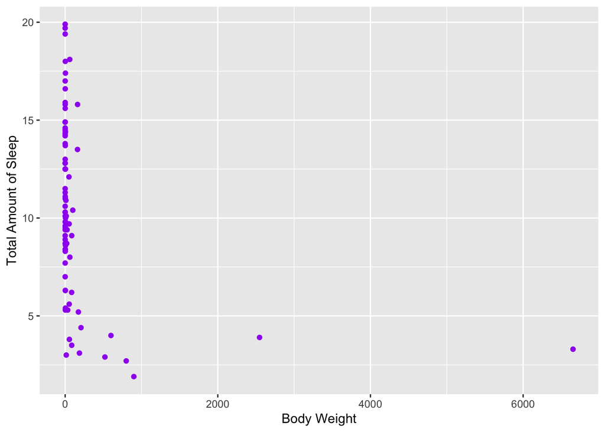

```r
plot1 <- ggplot(data=msleep) +
  geom_point(mapping = aes(x = bodywt, y=sleep_total), color = "purple") +
  xlab("Body Weight") +
  ylab("Total Amount of Sleep")
plot1
```

The explanatory variable seems to be body weight and the response variable is total amount of sleep.

####Question 4: Take the log of data until the data relationship seems less curved

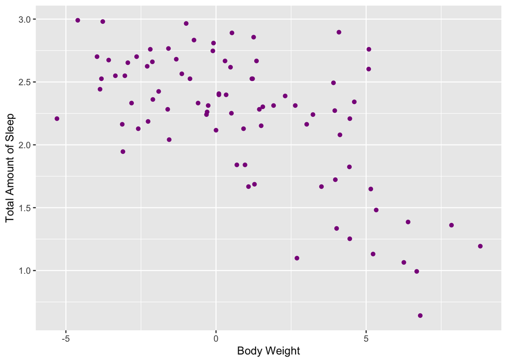

```r
plot2 <- ggplot(data=msleep) +
  geom_point(mapping = aes(x = log(bodywt), y=log(sleep_total)), color = "magenta4") +
  xlab("Body Weight") +
  ylab("Total Amount of Sleep")
plot2
```

Taking the log of both the explanatory and response variable seems to result in the best negative linear relationship.

####Question 5: Color code the scatter plot in problem 4 by the diet of the animals “vore” and add a title to your scatter plot. Use and show R code to produce the scatter plot.

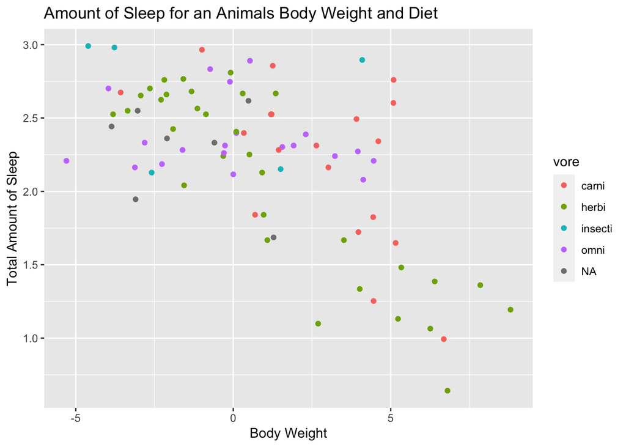

```r
plot3 <- ggplot(data=msleep) +
  geom_point(mapping = aes(x = log(bodywt), y=log(sleep_total), color = vore)) +
  xlab("Body Weight") +
  ylab("Total Amount of Sleep") +
  ggtitle("Amount of Sleep for an Animals Body Weight and Diet")

plot3
```

####Question 6:

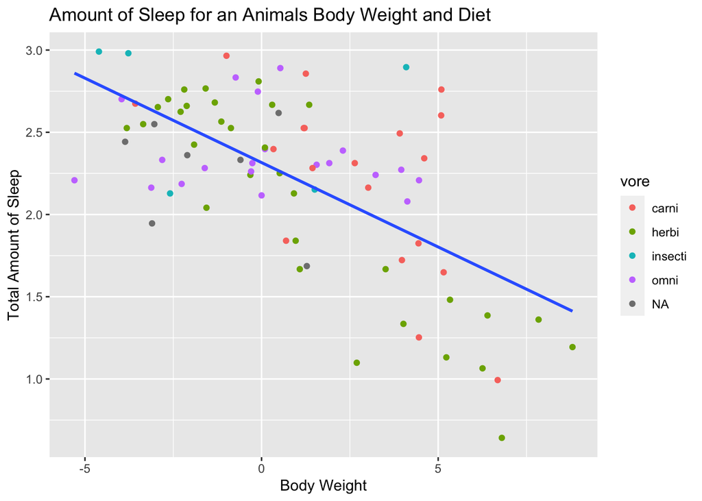

```r
plot4 <- ggplot(data=msleep) +
  geom_point(mapping = aes(x = log(bodywt), y=log(sleep_total), color = vore)) +
  geom_smooth(method=lm, mapping=aes(x=log(bodywt),y=log(sleep_total)), se=FALSE) +
  xlab("Body Weight") +
  ylab("Total Amount of Sleep") +
  ggtitle("Amount of Sleep for an Animals Body Weight and Diet")

plot4
```

####Question 7: Now use R code to change the appearance of the regression line. The regression line should be dashed and black.

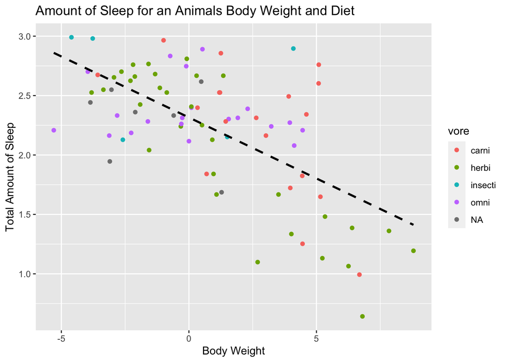

```r
plot5 <- ggplot(data=msleep) +
  geom_point(mapping = aes(x = log(bodywt), y=log(sleep_total), color = vore)) +
  geom_smooth(method=lm, mapping=aes(x=log(bodywt),y=log(sleep_total)), se=FALSE, color="black", linetype="dashed")  +
  xlab("Body Weight") +
  ylab("Total Amount of Sleep") +
  ggtitle("Amount of Sleep for an Animals Body Weight and Diet")

plot5
```

####Question 8: Use a dplyr function to modify the msleep data table so that it only shows the vore types that are carinvores (carni).

```r
msleep%>%
  filter(vore == "carni")
```

```
## # A tibble: 19 × 11
##    name   genus vore  order conservation sleep_total sleep_rem sleep_cycle awake
##    <chr>  <chr> <chr> <chr> <chr>              <dbl>     <dbl>       <dbl> <dbl>
##  1 Cheet… Acin… carni Carn… lc                  12.1      NA        NA      11.9
##  2 North… Call… carni Carn… vu                   8.7       1.4       0.383  15.3
##  3 Dog    Canis carni Carn… domesticated        10.1       2.9       0.333  13.9
##  4 Long-… Dasy… carni Cing… lc                  17.4       3.1       0.383   6.6
##  5 Domes… Felis carni Carn… domesticated        12.5       3.2       0.417  11.5
##  6 Pilot… Glob… carni Ceta… cd                   2.7       0.1      NA      21.4
##  7 Gray … Hali… carni Carn… lc                   6.2       1.5      NA      17.8
##  8 Thick… Lutr… carni Dide… lc                  19.4       6.6      NA       4.6
##  9 Slow … Nyct… carni Prim… <NA>                11        NA        NA      13
## 10 North… Onyc… carni Rode… lc                  14.5      NA        NA       9.5
## 11 Tiger  Pant… carni Carn… en                  15.8      NA        NA       8.2
## 12 Jaguar Pant… carni Carn… nt                  10.4      NA        NA      13.6
## 13 Lion   Pant… carni Carn… vu                  13.5      NA        NA      10.5
## 14 Caspi… Phoca carni Carn… vu                   3.5       0.4      NA      20.5
## 15 Commo… Phoc… carni Ceta… vu                   5.6      NA        NA      18.4
## 16 Bottl… Turs… carni Ceta… <NA>                 5.2      NA        NA      18.8
## 17 Genet  Gene… carni Carn… <NA>                 6.3       1.3      NA      17.7
## 18 Arcti… Vulp… carni Carn… <NA>                12.5      NA        NA      11.5
## 19 Red f… Vulp… carni Carn… <NA>                 9.8       2.4       0.35   14.2
## # ℹ 2 more variables: brainwt <dbl>, bodywt <dbl>
```

####Question 9: Use a dplyr functions to modify the msleep data table so that it only shows the variables name, vore, bodywt and conservation. Also, your data table should only show domesticated animals that have a bodyweight that is greater than 50 kilograms.

```r
msleep%>%
  select(name, vore, bodywt, conservation)%>%
  filter(conservation == "domesticated")%>%
  filter(bodywt >= 50)%>%
  arrange(desc(bodywt))
```

```
## # A tibble: 5 × 4
##   name   vore  bodywt conservation
##   <chr>  <chr>  <dbl> <chr>
## 1 Cow    herbi  600   domesticated
## 2 Horse  herbi  521   domesticated
## 3 Donkey herbi  187   domesticated
## 4 Pig    omni    86.2 domesticated
## 5 Sheep  herbi   55.5 domesticated
```

####Question 10: Use the group_by and summarize commands to find the mean sleep_total value for each level of the variable vore.

```r
msleep%>%
  select(sleep_total, vore)%>%
  group_by(vore) %>%
  summarize(MeanSleep_total = mean(sleep_total))
```

```
## # A tibble: 5 × 2
##   vore    MeanSleep_total
##   <chr>             <dbl>
## 1 carni             10.4
## 2 herbi              9.51
## 3 insecti           14.9
## 4 omni              10.9
## 5 <NA>              10.2
```

####Question 11: Use dplyr functions to modify the msleep data table so that it only shows the variables name, vore, bodywt and sleep_total. Also create a new variable in your data table that gives a ratio of sleep totals to body weight.

A partial representation of the table is given below. Note that the values for the new variable ratio is listed in descending order. Use dplyr coding to produce and display the first 15 rows of the data table.

```r
msleep%>%
  select(name, vore, bodywt, sleep_total)%>%
  mutate(sleeptobodywt = round((bodywt/sleep_total)))%>%
  arrange(desc(sleeptobodywt))%>%
  print(n=15)
```

```
## # A tibble: 83 × 5
##    name                 vore  bodywt sleep_total sleeptobodywt
##    <chr>                <chr>  <dbl>       <dbl>         <dbl>
##  1 African elephant     herbi 6654           3.3          2016
##  2 Asian elephant       herbi 2547           3.9           653
##  3 Giraffe              herbi  900.          1.9           474
##  4 Pilot whale          carni  800           2.7           296
##  5 Horse                herbi  521           2.9           180
##  6 Cow                  herbi  600           4             150
##  7 Donkey               herbi  187           3.1            60
##  8 Brazilian tapir      herbi  208.          4.4            47
##  9 Bottle-nosed dolphin carni  173.          5.2            33
## 10 Caspian seal         carni   86           3.5            25
## 11 Sheep                herbi   55.5         3.8            15
## 12 Gray seal            carni   85           6.2            14
## 13 Lion                 carni  161.         13.5            12
## 14 Tiger                carni  163.         15.8            10
## 15 Jaguar               carni  100          10.4            10
## # ℹ 68 more rows
```